# Emhart Stud Welding Process for Madalinski

## Notebook Contents

[figure not shown]

# 1. Business Understanding

## 1.1 Business Problem

Process optimization for stud welding technology

## 1.2 Client(s)

Brian Madalinski, stud weld process engineer

## 1.3 Objective

*The goal is to understand what features contribute most to Weld Out of Process and create a model that can predict if a certain weld will cause an out of process condition.*

## 1.4 Description

Emhart stud welding is a vital process to the Body Shop in ensuring the joining integrity of the car body as it is being pieced and welded together prior to going into the paint process. Currently there are multiple welding processes to make this happen. Stud welding is one of these processes.

# 2. Data Understanding

## 2.1 Import Libraries

```python
#Ignore warnings
import warnings
warnings.filterwarnings('ignore')

# Import widgets
import ipywidgets as widgets

# Handle table-like data and matrices
import numpy as np
import pandas as pd

# Visualizations
import matplotlib.pyplot as plt
import matplotlib as mpl
import matplotlib.pylab as pylab
import seaborn as sns

# Configure visualizations
%matplotlib inline
mpl.style.use('ggplot')
sns.set_style('white')
pylab.rcParams['figure.figsize'] = 8 , 6

# Modelling Helprs
from sklearn.preprocessing import LabelEncoder, Imputer, Normalizer, scale
from sklearn.cross_validation import train_test_split, StratifiedKFold
from sklearn.feature_selection import RFECV

def plot_histograms( df , variables , n_rows , n_cols ):
    fig = plt.figure( figsize = ( 16 , 12 ) )
    for i, var_name in enumerate( variables ):
        ax=fig.add_subplot( n_rows , n_cols , i+1 )
        df[ var_name ].hist( bins=10 , ax=ax )
        ax.set_title( 'Skew: ' + str( round( float( df[ var_name ].skew() ) , ) ) ) # + ' ' + var_name ) #var_name+" Distribution")
        ax.set_xticklabels( [] , visible=False )
        ax.set_yticklabels( [] , visible=False )
    fig.tight_layout()  # Improves appearance a bit.
    plt.show()

def plot_distribution( df , var , target , **kwargs ):
    row = kwargs.get( 'row' , None )
    col = kwargs.get( 'col' , None )
    facet = sns.FacetGrid( df , hue=target , aspect=4 , row = row , col = col )
    facet.map( sns.kdeplot , var , shade= True )
    facet.set( xlim=( 0 , df[ var ].max() ) )
    facet.add_legend()

def plot_categories( df , cat , target , **kwargs ):
    row = kwargs.get( 'row' , None )
    col = kwargs.get( 'col' , None )
    facet = sns.FacetGrid( df , row = row , col = col )
    facet.map( sns.barplot , cat , target )
    facet.add_legend()

def plot_correlation_map( df ):
    corr = df.corr()
    _ , ax = plt.subplots( figsize =( 12 , 10 ) )
    cmap = sns.diverging_palette( 220 , 10 , as_cmap = True )
    _ = sns.heatmap(
        corr,
        cmap = cmap,
        square=True,
        cbar_kws={ 'shrink' : .9 },
        ax=ax,
        annot = True,
        annot_kws = { 'fontsize' : 12 }
    )

def describe_more( df ):
    var = [] ; l = [] ; t = []
    for x in df:
        var.append( x )
        l.append( len( pd.value_counts( df[ x ] ) ) )
        t.append( df[ x ].dtypes )
    levels = pd.DataFrame( { 'Variable' : var , 'Levels' : l , 'Datatype' : t } )
    levels.sort_values( by = 'Levels' , inplace = True )
    return levels

def plot_variable_importance( X , y ):
    tree = DecisionTreeClassifier( random_state = 99 )
    tree.fit( X , y )
    plot_model_var_imp( tree , X , y )

def plot_model_var_imp( model , X , y ):
    imp = pd.DataFrame(
        model.feature_importances_  ,
        columns = [ 'Importance' ] ,
        index = X.columns
    )
    imp = imp.sort_values( [ 'Importance' ] , ascending = True )
    imp[ : 10 ].plot( kind = 'barh' )
    print (model.score( X , y ))
```

```
C:\Program Files (x86)\Microsoft Visual Studio\Shared\Anaconda3_64\lib\site-packages\sklearn\cross_validation.py:41: DeprecationWarning: This module was deprecated in version 0.18 in favor of the model_selection module into which all the refactored classes and functions are moved. Also note that the…
  "This module will be removed in 0.20.", DeprecationWarning)
```

## 2.2 Load the Data

Now that our packages are loaded, let's read in and take a peak at the data

```python
# The dataset came in 2 csv files and many xml files which I had to clean and tidy in Spyder prior to generating 1 additional csv for the process data
#fault_data = pd.read_csv("C:\\Users\\EISELJA\\Desktop\\EmhartData\\Faults.csv")
#measurement_data = pd.read_csv("C:\\Users\\EISELJA\\Desktop\\EmhartData\\MeasurementData.csv")
process_data = pd.read_csv("C:\\Users\\EISELJA\\Desktop\\EmhartData\\ProcessData.csv")
```

## 2.3 Feature Understanding with units of measure for process data

- Device Name: Robot ID
- Type: WIP or WOP, Weld In Parameter or Weld out of Parameter (OK vs NOK)
- Fault Number: If there was a fault the corresponding fault classification
- Stud-ID: Stud Number
- Carbody ID: Carbody ID (Does this come from PLUS?)
- Remark:
- Date/Time: Date and Time
- Application: Steel or Cleanflash Aluminum
- Outlet/Feeder/Tool: Self-Explanatory
- Tool type: Categorical Feature of Different Stud Weld tools
- MAC Process: Not Active for all records
- MAC Reference/-current: Not Used
- System Weld Counter: For a gun at given time, how many welds since last time the gun was reset
- Tool Weld Counter: A gun at given time since resest
- Outlet Weld Counter WOP: NOK controler is capable of 3 guns, WOP counter
- Outlet Weld Counter: Same thing but total
- Optimization: Do not use
- Clean Time: Aluminum welding precleaning time
- Peak/Drop Voltage: Not used (V)
- Mode: Force / Position Mode Try to achieve Force mode
- Stickout (Ref/Actual): How far stud sticks past the reference sustainer, must have more stickout (mm)
- Droptime (Ref/Actual): How long it takes from top position for linear motor to bottom position (ms)
- Weldmode: Steel = Normal, Aluminum
- Message: Not used
- Pilot Weldcurrent Arc Voltage Reference (Up): Strikes the arc and cleans the stud (V)
- Pilot Weldcurrent Arc Voltage Minimum (Up): Strikes the arc and cleans the stud (V)
- Pilot Weldcurrent Arc Voltage Maximum (Up): Strikes the arc and cleans the stud (V)
- Pilot Weldcurrent Arc Voltage Actual (Up): Strikes the arc and cleans the stud (V)
- Main Weldcurent Voltage Reference (Us): Main welding measure (V)
- Main Welcurrent Voltage Minimum (Us): Main welding measure (V)
- Main Weldcurrent Voltage Maximum (Us): Main welding measure (V)
- Main Weldcurrent Voltage Actual (Us): Main welding measure (V)
- Weldcurrent Reference (Is): Main welding measure (A)
- Weldcurrent Minimum (Is): Main welding measure (A)
- Weldcurrent Maximum (Is): Main welding measure (A)
- Weldcurrent Actual (Is): Main welding measure (A)
- Weldtime Reference (It): Main welding measure (ms)
- Weldtime Minimum (It): Main welding measure (ms)
- Weldtime Maximum (It): Main welding measure (ms)
- Weldtime Actual (It): Main Welding Measure (ms)
- Weld Energy Reference (Es): Main welding measure (J)
- Weld Energy Minimum (Es): Main welding measure (J)
- Weld Energy Maximum (Es): Main welding measure (J)
- Weld Energy Actual (Es): Main welding measure (J)
- Lift Height Reference: Programmed the linear motor pulls the stud up (mm)
- Lift Height Minimum: Programmed the linear motor pulls the stud up (mm)
- Lift Height Maximum: Programmed the linear motor pulls the stud up (mm)
- Lift Height Actual: Programmed the linear motor pulls the stud up (mm)
- Penetration Reference (P): How far down the linear motor pushes the metal (mm)
- Penetration Minimum (P): How far down the linear motor pushes the metal (mm)
- Penetration Maximum (P): How far down the linear motor pushes the metal (mm)
- Penetration Actual (P): How far down the linear motor pushes the metal (mm)

## 3.1 Check for missing values

```
The current shape of our data is : (190790, 49)
```

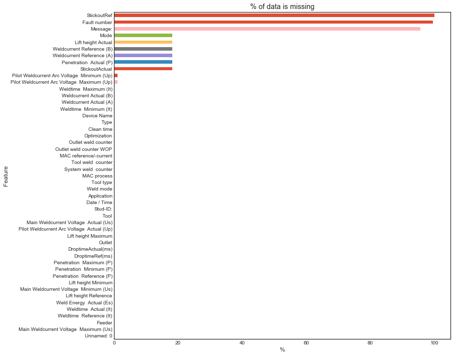

```python
# The shape of our data
print("The current shape of our data is : {}".format(process_data.shape))
missing = pd.Series(process_data.isnull().sum()/190790*100)
missing.dropna(axis = 0, how = 'all', inplace = True)
missing_sorted = missing.sort_values(ascending = True)
plt.figure(figsize = (12,12))
missing_sorted.plot(kind = 'barh')
plt.title("% of data is missing")
plt.ylabel("Feature")
plt.xlabel('%')
plt.show()
```

```python
# Seperate features which are actuals from those that are static reference lines or static maximum/minimum values
df = process_data[['Type', 'Device Name', 'Fault number', 'Stud-ID:', 'Date / Time',
       'Application', 'Tool type','System weld  counter', 'Tool weld  counter', 'Outlet weld counter WOP',
       'Outlet weld counter', 'Optimization', 'Clean time', 'Mode',
       'Weld mode','Pilot Weldcurrent Arc Voltage  Actual (Up)','Main Weldcurrent Voltage  Actual (Us)',
                   'Weldtime  Actual (It)','Weld Energy  Actual (Es)','Lift height Actual','Penetration  Actual (P)',
                  'Weldcurrent Actual (A)','Weldcurrent Actual (B)','DroptimeActual(ms)','StickoutActual','Outlet', 'Feeder', 'Tool']]
```

```python
#Drop categorical columns
df.drop(columns = ['Fault number','Stud-ID:', 'Date / Time','Application', 'Tool type',
                   'System weld  counter','Tool weld  counter', 'Outlet weld counter WOP','Outlet weld counter',
                  'Optimization', 'Mode', 'Weld mode', 'Outlet','Feeder', 'Tool'],inplace = True)
```

## 3.2 Merge DataFrames (N/A)

## 3.3 Transform categorical features into binary (N/A)

## 3.4 Feature Engineering (N/A)

## 3.5 Statistical Summaries and EDA

### 3.5a Statistical Overview

This dataset has:

```python
# This dataset currently contains 13 columns and 190790 observations
df.shape
```

```
(190790, 13)
```

```python
# Check the data types of our features
df.info()
```

```
<class 'pandas.core.frame.DataFrame'>
RangeIndex: 190790 entries, 0 to 190789
Data columns (total 13 columns):
Type                                          190790 non-null object
Device Name                                   190790 non-null object
Clean time                                    190790 non-null int64
Pilot Weldcurrent Arc Voltage  Actual (Up)    190790 non-null int64
Main Weldcurrent Voltage  Actual (Us)         190790 non-null int64
Weldtime  Actual (It)                         190790 non-null int64
Weld Energy  Actual (Es)                      190790 non-null int64
Lift height Actual                            156015 non-null float64
Penetration  Actual (P)                       156017 non-null float64
Weldcurrent Actual (A)                        190783 non-null float64
Weldcurrent Actual (B)                        190783 non-null float64
DroptimeActual(ms)                            190790 non-null int64
StickoutActual                                156017 non-null float64
dtypes: float64(5), int64(6), object(2)
memory usage: 18.9+ MB
```

```python
# Drop the records where Lift Height Actual Contains NaN values
df.dropna(subset = ['Lift height Actual'], inplace = True)
```

```python
# Recheck the data frame for consistency
df.info()
```

```
<class 'pandas.core.frame.DataFrame'>
Int64Index: 156015 entries, 0 to 190789
Data columns (total 13 columns):
Type                                          156015 non-null object
Device Name                                   156015 non-null object
Clean time                                    156015 non-null int64
Pilot Weldcurrent Arc Voltage  Actual (Up)    156015 non-null int64
Main Weldcurrent Voltage  Actual (Us)         156015 non-null int64
Weldtime  Actual (It)                         156015 non-null int64
Weld Energy  Actual (Es)                      156015 non-null int64
Lift height Actual                            156015 non-null float64
Penetration  Actual (P)                       156015 non-null float64
Weldcurrent Actual (A)                        156015 non-null float64
Weldcurrent Actual (B)                        156015 non-null float64
DroptimeActual(ms)                            156015 non-null int64
StickoutActual                                156015 non-null float64
dtypes: float64(5), int64(6), object(2)
memory usage: 16.7+ MB
```

```python
# Looks like 0.476% of stud welds were not ok or WOP and 99.524% of studs were WIP for the population
# NOTE When performing cross_validation, maintain this ratio!
ok_rate = df.Type.value_counts()/156015
ok_rate
```

```
WIP    0.995244
WOP    0.004756
Name: Type, dtype: float64
```

```python
# Display the statistical summaries of our dataset
df.describe()
```

|  | Clean time | Pilot Weldcurrent Arc Voltage Actual (Up) | Main Weldcurrent Voltage Actual (Us) | Weldtime Actual (It) | Weld Energy Actual (Es) | Lift height Actual | Penetration Actual (P) | Weldcurrent Actual (A) | Weldcurrent Actual (B) | DroptimeActual(ms) | StickoutActual |
| --- | --- | --- | --- | --- | --- | --- | --- | --- | --- | --- | --- |
| count | 156015.000000 | 156015.000000 | 156015.000000 | 156015.000000 | 156015.000000 | 156015.000000 | 156015.000000 | 156015.000000 | 156015.000000 | 156015.000000 | 156015.000000 |
| mean | 1.917226 | 18.805000 | 23.569073 | 550.185636 | 1060.238176 | 95.450578 | 89.891882 | 723.351857 | 629.636702 | 61.818223 | 303.413967 |
| std | 8.655422 | 1.314403 | 1.880906 | 94.988347 | 190.172202 | 42.997099 | 29.746729 | 545.897796 | 251.243478 | 33.255977 | 95.360758 |
| min | 0.000000 | 0.000000 | 0.000000 | 0.000000 | 0.000000 | 71.000000 | 1.000000 | 0.000000 | 0.000000 | 0.000000 | 152.000000 |
| 25% | 0.000000 | 18.000000 | 22.000000 | 500.000000 | 948.000000 | 79.000000 | 67.000000 | 0.000000 | 400.000000 | 30.000000 | 249.000000 |
| 50% | 0.000000 | 19.000000 | 23.000000 | 565.000000 | 1036.000000 | 79.000000 | 90.000000 | 1130.000000 | 500.000000 | 62.000000 | 277.000000 |
| 75% | 0.000000 | 20.000000 | 25.000000 | 614.000000 | 1136.000000 | 101.000000 | 108.000000 | 1160.000000 | 820.000000 | 93.000000 | 321.000000 |
| max | 64.000000 | 39.000000 | 44.000000 | 977.000000 | 4100.000000 | 302.000000 | 245.000000 | 1440.000000 | 1240.000000 | 194.000000 | 967.000000 |

### 3.5b Correlation Matrix and Heatmap

**Moderate Positively Correlated Features:**

**Moderate Negatively Correlated Features:**

- Weldcurrent Actual and Drop time

**Stop and Think:**

- What features affect our target variable the most (Type)?
- What features have strong correlations with each other?
- Can we do a more in depth examination of these features?

**Summary**

```python
# Correlation Matrix
corr = df.corr()
corr = (corr)
corr
```

|  | Clean time | Pilot Weldcurrent Arc Voltage Actual (Up) | Main Weldcurrent Voltage Actual (Us) | Weldtime Actual (It) | Weld Energy Actual (Es) | Lift height Actual | Penetration Actual (P) | Weldcurrent Actual (A) | Weldcurrent Actual (B) | DroptimeActual(ms) | StickoutActual |
| --- | --- | --- | --- | --- | --- | --- | --- | --- | --- | --- | --- |
| Clean time | 1.000000 | -0.111623 | -0.132298 | 0.151204 | 0.009886 | 0.821220 | 0.449872 | 0.010671 | 0.145214 | 0.199492 | 0.536851 |
| Pilot Weldcurrent Arc Voltage Actual (Up) | -0.111623 | 1.000000 | 0.401082 | -0.227003 | 0.182610 | 0.018065 | -0.133243 | -0.363445 | 0.399806 | 0.298211 | -0.115921 |
| Main Weldcurrent Voltage Actual (Us) | -0.132298 | 0.401082 | 1.000000 | -0.419341 | 0.393747 | 0.141324 | 0.381669 | -0.681014 | 0.705151 | 0.673098 | 0.078573 |
| Weldtime Actual (It) | 0.151204 | -0.227003 | -0.419341 | 1.000000 | 0.438764 | 0.013745 | 0.026980 | 0.723889 | -0.676838 | -0.488100 | 0.079401 |
| Weld Energy Actual (Es) | 0.009886 | 0.182610 | 0.393747 | 0.438764 | 1.000000 | 0.033118 | 0.351122 | -0.010113 | 0.216773 | 0.111491 | 0.120344 |
| Lift height Actual | 0.821220 | 0.018065 | 0.141324 | 0.013745 | 0.033118 | 1.000000 | 0.350739 | -0.189292 | 0.295827 | 0.353997 | 0.648367 |
| Penetration Actual (P) | 0.449872 | -0.133243 | 0.381669 | 0.026980 | 0.351122 | 0.350739 | 1.000000 | -0.159850 | 0.296323 | 0.361670 | 0.312575 |
| Weldcurrent Actual (A) | 0.010671 | -0.363445 | -0.681014 | 0.723889 | -0.010113 | -0.189292 | -0.159850 | 1.000000 | -0.901485 | -0.772600 | -0.098759 |
| Weldcurrent Actual (B) | 0.145214 | 0.399806 | 0.705151 | -0.676838 | 0.216773 | 0.295827 | 0.296323 | -0.901485 | 1.000000 | 0.771038 | 0.194579 |
| DroptimeActual(ms) | 0.199492 | 0.298211 | 0.673098 | -0.488100 | 0.111491 | 0.353997 | 0.361670 | -0.772600 | 0.771038 | 1.000000 | 0.203282 |
| StickoutActual | 0.536851 | -0.115921 | 0.078573 | 0.079401 | 0.120344 | 0.648367 | 0.312575 | -0.098759 | 0.194579 | 0.203282 | 1.000000 |

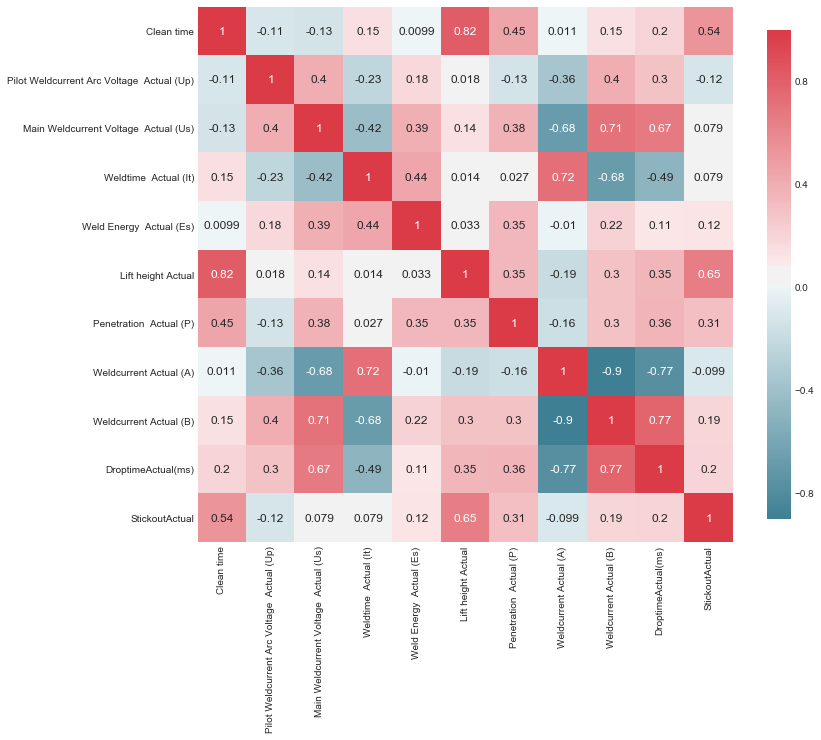

```python
# Look for highly correlated variables
plot_correlation_map(df)
```

### Let's take a look at the kernel density distribution of the feature actuals contrasting WIP vs WOP

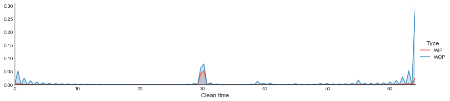

```python
plot_distribution(df, var = 'Clean time', target = 'Type')
```

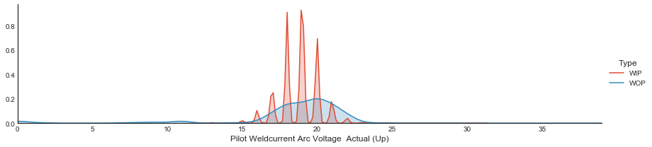

```python
# Look at the distribution of actuals against the target variable
plot_distribution(df , var = 'Pilot Weldcurrent Arc Voltage  Actual (Up)' , target = 'Type')
```

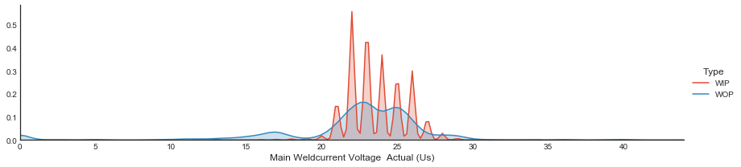

```python
plot_distribution(df, var = 'Main Weldcurrent Voltage  Actual (Us)', target = 'Type')
```

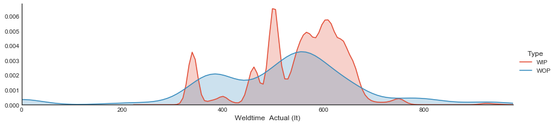

```python
plot_distribution(df, var = 'Weldtime  Actual (It)', target = 'Type')
```

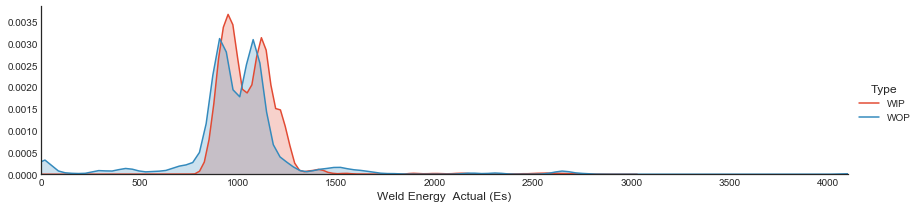

```python
plot_distribution(df, var = 'Weld Energy  Actual (Es)', target = 'Type')
```

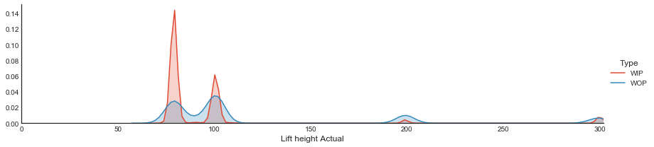

```python
plot_distribution(df, var = 'Lift height Actual', target = 'Type')
```

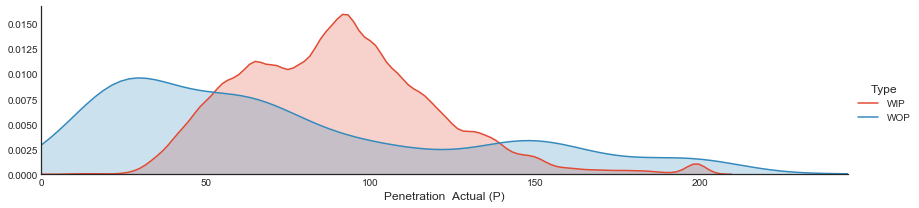

```python
plot_distribution(df, var = 'Penetration  Actual (P)', target = 'Type')
```

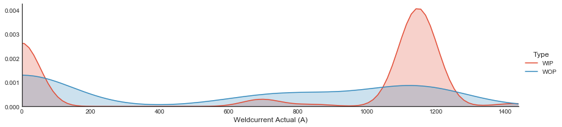

```python
plot_distribution(df, var = 'Weldcurrent Actual (A)', target = 'Type')
```

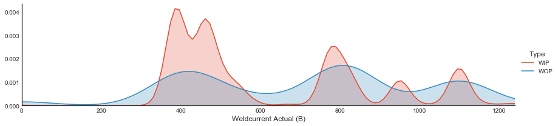

```python
plot_distribution(df, var = 'Weldcurrent Actual (B)', target = 'Type')
```

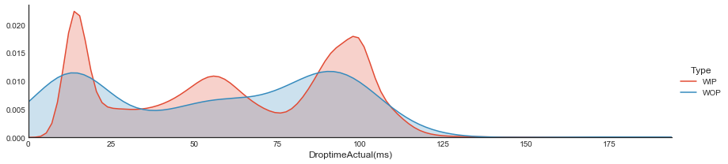

```python
plot_distribution(df, var = 'DroptimeActual(ms)', target = 'Type')
```

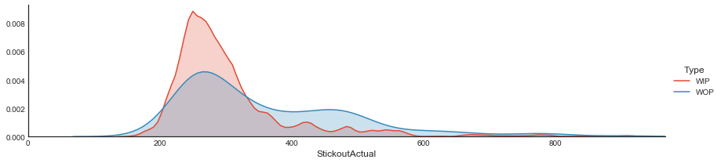

```python
plot_distribution(df, var = 'StickoutActual', target = 'Type')
```

### Stop and think if there is any other way to aggregate these features

- By a particular Device?

### First let's look at Weld in Process (WIP) vs Weld out of Process (WOP) by device name

```
Text(0.5,1,'WIP-WOP by Device Name')
```

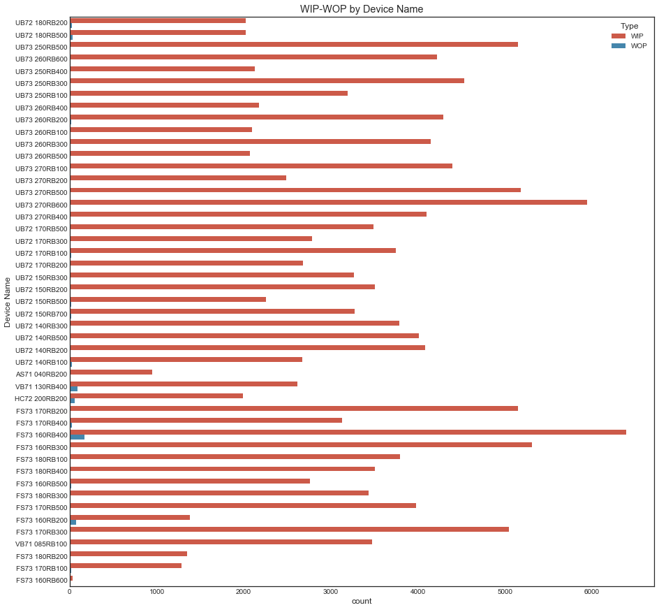

```python
f, ax = plt.subplots(figsize=(15, 15))
sns.countplot(y="Device Name", hue='Type', data=df).set_title("WIP-WOP by Device Name")
```

### Cancel out the noise and only focus on WOP by Device Name

```
Text(0.5,1,'WOP by Device Name')
```

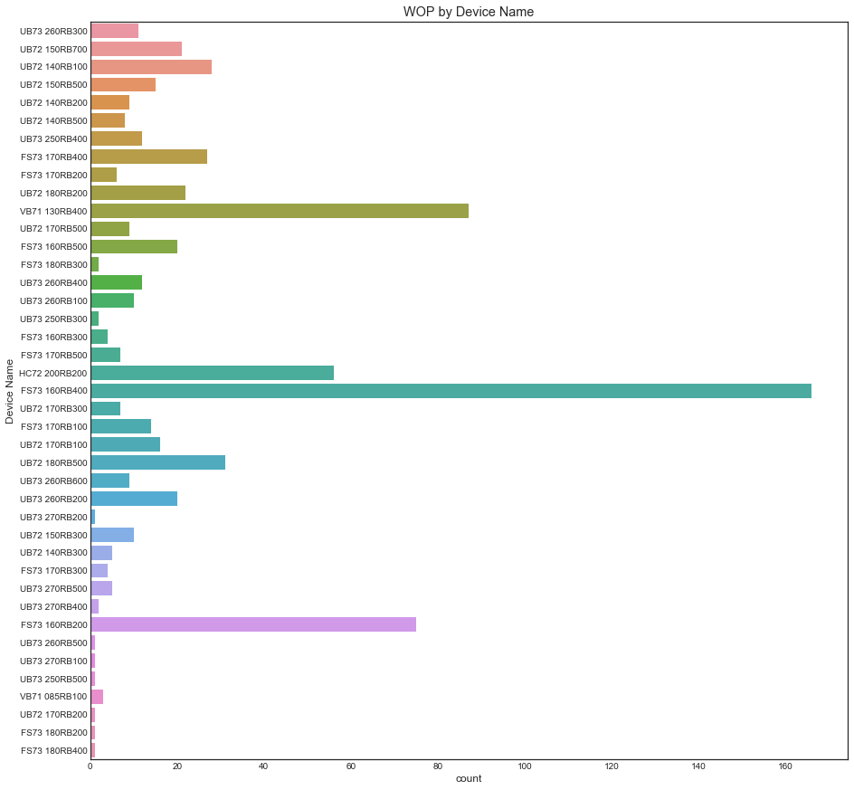

```python
# WOP by Device Name
f, ax = plt.subplots(figsize = ((15,15)))
wop = df[df['Type'] == 'WOP']
sns.countplot(y = 'Device Name', data = wop).set_title("WOP by Device Name")
```

### We can see rather quickly Device Name FS73 160RB400 has more WOP conditions than any other device

#### Let's take a deeper look at the features of FS73 160RB400 WOP welds compared to the population

```
Text(0.5,1,'Main Weldcurrent Voltage  Actual (Us)')
```

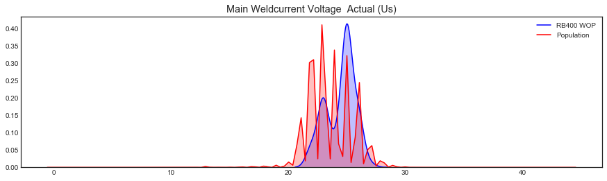

```python
#Sample FS73 160RB400 all welds
RB400 = df[df['Device Name'] == 'FS73 160RB400']

# Sample FS73 160RB400 WOP Type Welds
RB400_WOP = df[(df['Type'] == 'WOP') & (df['Device Name']== 'FS73 160RB400')]

# Kernel Density Plot
fig = plt.figure(figsize=(15,4),)
ax=sns.kdeplot(RB400_WOP['Main Weldcurrent Voltage  Actual (Us)'], color = 'b', shade=True, label='RB400 WOP')
ax=sns.kdeplot(df['Main Weldcurrent Voltage  Actual (Us)'], color = 'r', shade=True, label='Population')
plt.title('Main Weldcurrent Voltage  Actual (Us)')
```

```
Text(0.5,1,'Weldtime  Actual (It)')
```

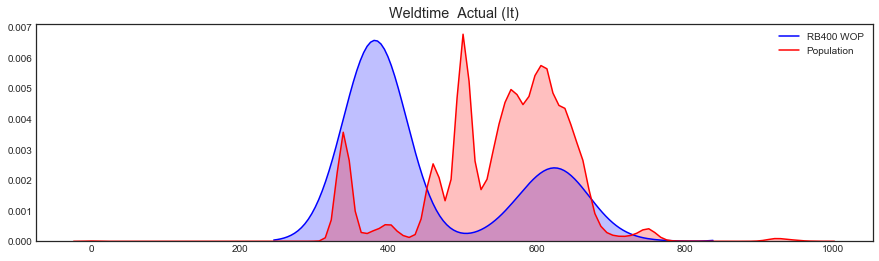

```python
# Kernel Density Plot
fig = plt.figure(figsize=(15,4),)
ax=sns.kdeplot(RB400_WOP['Weldtime  Actual (It)'], color = 'b', shade=True, label='RB400 WOP')
ax=sns.kdeplot(df['Weldtime  Actual (It)'], color = 'r', shade=True, label='Population')
plt.title('Weldtime  Actual (It)')
```

```
Text(0.5,1,'Weld Energy  Actual')
```

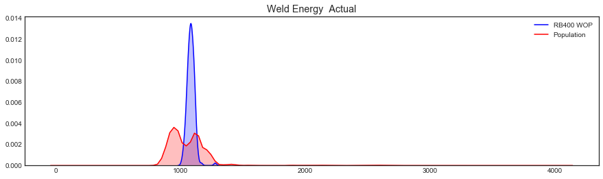

```python
# Kernel Density Plot
fig = plt.figure(figsize=(15,4),)
ax=sns.kdeplot(RB400_WOP['Weld Energy  Actual (Es)'], color = 'b', shade=True, label='RB400 WOP')
ax=sns.kdeplot(df['Weld Energy  Actual (Es)'], color = 'r', shade=True, label='Population')
plt.title('Weld Energy  Actual')
```

```
Text(0.5,1,'Lift height Actual')
```

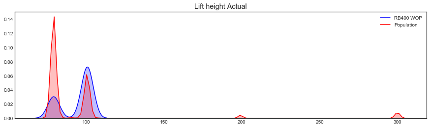

```python
# Kernel Density Plot
fig = plt.figure(figsize=(15,4),)
ax=sns.kdeplot(RB400_WOP['Lift height Actual'], color = 'b', shade=True, label='RB400 WOP')
ax=sns.kdeplot(df['Lift height Actual'], color = 'r', shade=True, label='Population')
plt.title('Lift height Actual')
```

```
Text(0.5,1,'Penetration  Actual (P)')
```

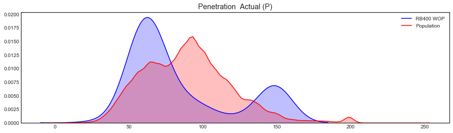

```python
# Kernel Density Plot
fig = plt.figure(figsize=(15,4),)
ax=sns.kdeplot(RB400_WOP['Penetration  Actual (P)'], color = 'b', shade=True, label='RB400 WOP')
ax=sns.kdeplot(df['Penetration  Actual (P)'], color = 'r', shade=True, label='Population')
plt.title('Penetration  Actual (P)')
```

```
Text(0.5,1,'DroptimeActual(ms)')
```

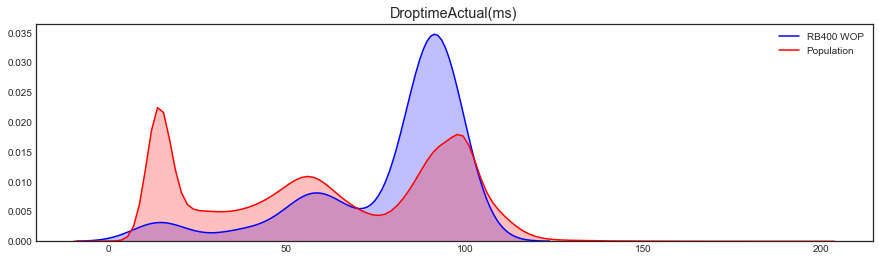

```python
# Kernel Density Plot
fig = plt.figure(figsize=(15,4),)
ax=sns.kdeplot(RB400_WOP['DroptimeActual(ms)'], color = 'b', shade=True, label='RB400 WOP')
ax=sns.kdeplot(df['DroptimeActual(ms)'], color = 'r', shade=True, label='Population')
plt.title('DroptimeActual(ms)')
```

```python
RB400['Type'].value_counts()
```

```
WIP    6392
WOP     166
Name: Type, dtype: int64
```

```python
RB400['Type'].value_counts()/6558
```

```
WIP    0.974687
WOP    0.025313
Name: Type, dtype: float64
```

### 2.5 % of the welds by FS73 160RB400 were out of process condition or 'WOP'

### Statistical Test for Correlation

#### One-Sample T-Test (Measuring Weldtime Actual)

A one sample t-test checks whether a sample mean differs from the population mean. Let's test to see whether the mean Weldtime Actual for FS73 160RB400 differs from the entire population.

**Hypothesis Testing:** Is there significant difference in the **means of Weldtime Actual** between FS73 160RB400 and the entire population?

- **Null Hypothesis**: *(H0 = pPS = pPP)* The null hypothesis would be that there is **no** difference in Weldtime Actual between FS73 160RB400 and the entire population.
- **Alternative Hypothesis:** *(HA:pPS != pPP)* The alternative hypothesis would be that there **is** a difference in mean Weldtime Actual between FS73 160RB400 and the entire population.

```python
# Let's compare the means of Weldtime Actual data against the Weldtime Actual population data
weldtime1 = df['Weldtime  Actual (It)'].mean()
weldtime2 = df[df['Device Name']=='FS73 160RB400']['Weldtime  Actual (It)'].mean()

print('The mean Weldtime Actual of the population is: ' + str(weldtime1))
print('The mean Weldtime Actual of FS73 160RB400 is: ' + str(weldtime2))
```

```
The mean Weldtime Actual of the population is: 550.1856359965388
The mean Weldtime Actual of FS73 160RB400 is: 555.3825861543154
```

## Conducting the T-Test

Let's conduct a t-test at **95% confidence level** and see if it correctly rejects the null hypothesis that the same comes from the same distribution as the population. To conduct a one-sample t-test, we can use the **stats.ttest_1samp()** function:

```python
import scipy.stats as stats
stats.ttest_1samp(a=  df[df['Device Name']=='FS73 160RB400']['Weldtime  Actual (It)'],
                  popmean = weldtime1, nan_policy ='omit')
```

```
Ttest_1sampResult(statistic=3.7015781278115187, pvalue=0.00021601991263819702)
```

### T-Test Result

The test result shows the **test statistic "t" is equal to 3.702**. This test statistic tells us how much the sample mean deviates from the null hypothesis. If the t-statistic lies **outside** the quantiles of the t-distribution corresponding to our confidence level and degrees of freedom, we reject the null hypothese. We can check the quantiles with **stats.t.ppf()**

### T-Test Quantile

If the test statistic value we calculated above **(3.702)** is outside the quartiles, then we can reject the null hypothesis.

```python
degree_freedom = len(df[df['Device Name']=='FS73 160RB400'])

LQ = stats.t.ppf(0.025, degree_freedom) # Left Quartile

RQ = stats.t.ppf(0.975, degree_freedom) # Right Quartile

print("The t-distirbution left quartile range is: " + str(LQ))
print("The t-distribution right quartile range is: " + str(RQ))
```

```
The t-distirbution left quartile range is: -1.9603257871749862
The t-distribution right quartile range is: 1.9603257871749857
```

### One-Sample T-Test Summary

**T-Test = 3.702 | P-Value = .000216 | Reject Null Hypothesis**

**Reject the null hypothesis because:**

- T-Test score is outside the quartiles
- P-value is lower than confidence level of 5%

Based on the statistical analysis of a one sample t-test, there seems to be some significant difference between the mean Weldtime Actual for FS73 160RB400 and the entire population mean Weldtime Actual. The low P-value of **.000216** at a 5% confidence level is a good indicator to **reject the null hypothesis**.

But this does not neccessarily mean that there is practical significance. We would have to conduct more experiments or maybe collect more data about the in order to come up with a more accurate finding.

## 4.0 Modeling the Data

The best model performance out of the four (Decision Tree Model, AdaBoost Model, Logisitc Regression Model, Random Forest Model) was **Decision Tree**

**Note on Base Rate**

- A **Base Rate Model** is a model that always selects the target variable's **majority class**. It's just used for reference to compare how better another model is against it. In this dataset, the majority class that will be predicted will be **WIPs**, which are welds that were in process.
- If you recall back to **Exploring the Data**, 97.5% of the FS73 160RB400 dataset contained WIPs (Welds in Process) and the remaining 2.5% contained WOPs (Welds out of process). The Base Rate Model would simply predict every stud weld as WIP and ignore all the WOPs.
- **Example**: The base rate accuracy for this data set, when classifying everything as WIPs, would be 97.5%, because 97.5% of the dataset are labeled as WIPs (Welds in process).

**Note: Evaluating the Model**

**Precision and Recall / Class Imbalance**

This dataset is an example of a class imbalance problem because of the skewed distribution of WIP vs WOP. More skewed the class means that accuracy breaks down.

In this case, evaluating our model’s algorithm based on **accuracy** is the **wrong** thing to measure. We would have to know the different errors that we care about and correct decisions. Accuracy alone does not measure an important concept that needs to be taken into consideration in this type of evaluation: **False Positive** and **False Negative** errors.

**False Positives (Type I Error)**: You predict that the weld will be in a WIP condition, but it is not.

**False Negatives (Type II Error)**: You predict that the weld will not be in a WIP condition, but it is.

In this problem, what type of errors do we care about more? False Positives or False Negatives?

[figure not shown]

**Note: Different Ways to Evaluate Classification Models**

1. **Predictive Accuracy:** How many does it get right?
2. **Speed:** How fast does it take for the model to deploy?
3. **Scalability:** Can the model handle large datasets?
4. **Robustness:** How well does the model handle outliers/missing values?
5. **Interpretability:** Is the model easy to understand?

[figure not shown]

## 4.1 Select a Model

```python
from sklearn.linear_model import LogisticRegression
from sklearn.preprocessing import LabelEncoder
from sklearn.model_selection import train_test_split
from sklearn.metrics import accuracy_score, classification_report, precision_score, recall_score, confusion_matrix, precision_recall_curve
from sklearn.preprocessing import RobustScaler

# Sample only the FS73 160RB400 DataFrame
RB400 = df[df['Device Name'] == 'FS73 160RB400']
RB400.drop(columns = ['Device Name'], axis = 1, inplace = True)
RB400.head()
```

|  | Type | Clean time | Pilot Weldcurrent Arc Voltage Actual (Up) | Main Weldcurrent Voltage Actual (Us) | Weldtime Actual (It) | Weld Energy Actual (Es) | Lift height Actual | Penetration Actual (P) | Weldcurrent Actual (A) | Weldcurrent Actual (B) | DroptimeActual(ms) | StickoutActual |
| --- | --- | --- | --- | --- | --- | --- | --- | --- | --- | --- | --- | --- |
| 5005 | WIP | 0 | 21 | 27 | 378 | 1132 | 101.0 | 76.0 | 0.0 | 1100.0 | 98 | 273.0 |
| 5019 | WIP | 0 | 22 | 29 | 383 | 1217 | 101.0 | 93.0 | 0.0 | 1100.0 | 103 | 284.0 |
| 5031 | WIP | 0 | 19 | 22 | 644 | 1219 | 79.0 | 92.0 | 1160.0 | 540.0 | 14 | 247.0 |
| 5042 | WIP | 0 | 19 | 23 | 635 | 1239 | 79.0 | 92.0 | 1170.0 | 540.0 | 15 | 249.0 |
| 5054 | WIP | 0 | 19 | 23 | 643 | 1240 | 79.0 | 88.0 | 1160.0 | 540.0 | 13 | 231.0 |

```python
# Aggregate the dataset between independent variables X and dependent variable y
X = RB400.iloc[:, 1:12]
y = RB400.iloc[:, 0]
```

```python
# Encode categorical data ['Type']
from sklearn.preprocessing import LabelEncoder
enc = LabelEncoder()
X.iloc[:, 0] = enc.fit_transform(X.iloc[:, 0])
y = enc.fit_transform(y)
```

```python
# Split the dataset into the Training set and Test set
from sklearn.model_selection import train_test_split
X_train, X_test, y_train, y_test = train_test_split(X, y, test_size = 0.2, random_state = 0)
```

```python
# Create base rate model
def base_rate_model(X) :
    y = np.zeros(X.shape[0])
    return y
```

```python
# Normalize the data with feature scaling
from sklearn.preprocessing import StandardScaler
sc = StandardScaler()
X_train = sc.fit_transform(X_train)
X_test = sc.transform(X_test)
```

```python
# Check accuracy of base rate model
y_base_rate = base_rate_model(X_test)
from sklearn.metrics import accuracy_score
print ("Base rate accuracy is %2.2f" % accuracy_score(y_test, y_base_rate))
```

```
Base rate accuracy is 0.97
```

```python
# Check training accuracy of Logistic Model
model = LogisticRegression(penalty='l2', C=1)
model.fit(X_train, y_train)
print ("Logistic accuracy is %2.2f" % accuracy_score(y_test, model.predict(X_test)))
```

```
Logistic accuracy is 0.97
```

```python
# Using 10 fold Cross-Validation to train our Logistic Regression Model
from sklearn import model_selection
kfold = model_selection.KFold(n_splits=10, random_state=7)
modelCV = LogisticRegression(class_weight = "balanced")
scoring = 'roc_auc'
results = model_selection.cross_val_score(modelCV, X_train, y_train, cv=kfold, scoring=scoring)
print("AUC: %.3f (%.3f)" % (results.mean(), results.std()))
```

```
AUC: 0.923 (0.017)
```

## 4.3 Build, Fit, Validate Model

### Logistic Regression V.S. Random Forest V.S. Decision Tree V.S. AdaBoost Model

```python
# Compare the Logistic Regression Model V.S. Base Rate Model V.S. Random Forest Model
from sklearn.metrics import roc_auc_score
from sklearn.metrics import classification_report
from sklearn.ensemble import RandomForestClassifier

from sklearn import tree
from sklearn.tree import DecisionTreeClassifier
from sklearn.linear_model import LogisticRegression
from sklearn.ensemble import ExtraTreesClassifier
from sklearn.ensemble import BaggingClassifier
from sklearn.ensemble import AdaBoostClassifier
from sklearn.ensemble import GradientBoostingClassifier
from sklearn.ensemble import VotingClassifier


print ("---Base Model---")
base_roc_auc = roc_auc_score(y_test, base_rate_model(X_test))
print ("Base Rate AUC = %2.2f" % base_roc_auc)
print(classification_report(y_test, base_rate_model(X_test)))

# Logisitc Regression Model
logis = LogisticRegression(class_weight = "balanced")
logis.fit(X_train, y_train)
print ("\n\n ---Logistic Model---")
logit_roc_auc = roc_auc_score(y_test, logis.predict(X_test))
print ("Logistic AUC = %2.2f" % logit_roc_auc)
print(classification_report(y_test, logis.predict(X_test)))

# Decision Tree Model
dtree = tree.DecisionTreeClassifier(
    #max_depth=3,
    class_weight="balanced",
    min_weight_fraction_leaf=0.01
    )
dtree = dtree.fit(X_train,y_train)
print ("\n\n ---Decision Tree Model---")
dt_roc_auc = roc_auc_score(y_test, dtree.predict(X_test))
print ("Decision Tree AUC = %2.2f" % dt_roc_auc)
print(classification_report(y_test, dtree.predict(X_test)))

# Random Forest Model
rf = RandomForestClassifier(
    n_estimators=1000,
    max_depth=None,
    min_samples_split=10,
    class_weight="balanced"
    #min_weight_fraction_leaf=0.02
    )
rf.fit(X_train, y_train)
print ("\n\n ---Random Forest Model---")
rf_roc_auc = roc_auc_score(y_test, rf.predict(X_test))
print ("Random Forest AUC = %2.2f" % rf_roc_auc)
print(classification_report(y_test, rf.predict(X_test)))


# Ada Boost
ada = AdaBoostClassifier(n_estimators=400, learning_rate=0.1)
ada.fit(X_train,y_train)
print ("\n\n ---AdaBoost Model---")
ada_roc_auc = roc_auc_score(y_test, ada.predict(X_test))
print ("AdaBoost AUC = %2.2f" % ada_roc_auc)
print(classification_report(y_test, ada.predict(X_test)))
```

```
---Base Model---
Base Rate AUC = 0.50
             precision    recall  f1-score   support

          0       0.97      1.00      0.98      1273
          1       0.00      0.00      0.00        39

avg / total       0.94      0.97      0.96      1312



 ---Logistic Model---
Logistic AUC = 0.89
             precision    recall  f1-score   support

          0       1.00      0.81      0.90      1273
          1       0.14      0.97      0.24        39

avg / total       0.97      0.82      0.88      1312



 ---Decision Tree Model---
Decision Tree AUC = 0.89
             precision    recall  f1-score   support

          0       1.00      0.86      0.92      1273
          1       0.17      0.92      0.29        39

avg / total       0.97      0.86      0.91      1312



 ---Random Forest Model---
Random Forest AUC = 0.67
             precision    recall  f1-score   support

          0       0.98      0.98      0.98      1273
          1       0.41      0.36      0.38        39

avg / total       0.96      0.97      0.96      1312



 ---AdaBoost Model---
AdaBoost AUC = 0.51
             precision    recall  f1-score   support

          0       0.97      1.00      0.99      1273
          1       1.00      0.03      0.05        39

avg / total       0.97      0.97      0.96      1312
```

## 5.0 Evaluation

## ROC Graph

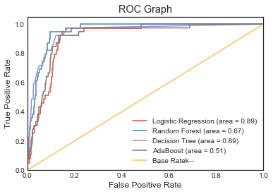

```python
# Create ROC Graph
from sklearn.metrics import roc_curve
fpr, tpr, thresholds = roc_curve(y_test, logis.predict_proba(X_test)[:,1])
rf_fpr, rf_tpr, rf_thresholds = roc_curve(y_test, rf.predict_proba(X_test)[:,1])
dt_fpr, dt_tpr, dt_thresholds = roc_curve(y_test, dtree.predict_proba(X_test)[:,1])
ada_fpr, ada_tpr, ada_thresholds = roc_curve(y_test, ada.predict_proba(X_test)[:,1])

plt.figure()

# Plot Logistic Regression ROC
plt.plot(fpr, tpr, label='Logistic Regression (area = %0.2f)' % logit_roc_auc)

# Plot Random Forest ROC
plt.plot(rf_fpr, rf_tpr, label='Random Forest (area = %0.2f)' % rf_roc_auc)

# Plot Decision Tree ROC
plt.plot(dt_fpr, dt_tpr, label='Decision Tree (area = %0.2f)' % dt_roc_auc)

# Plot AdaBoost ROC
plt.plot(ada_fpr, ada_tpr, label='AdaBoost (area = %0.2f)' % ada_roc_auc)

# Plot Base Rate ROC
plt.plot([0,1], [0,1],label='Base Rate' 'k--')

plt.xlim([0.0, 1.0])
plt.ylim([0.0, 1.05])
plt.xlabel('False Positive Rate')
plt.ylabel('True Positive Rate')
plt.title('ROC Graph')
plt.legend(loc="lower right")
plt.show()
```

### 5.1 Model Performance

**Confusion Matrix of Decision Tree vs Logisitc Regression**

Decsion Tree rules the confusion matrix test

```python
# Predicting the Test set results
y_pred1 = dtree.predict(X_test)
y_pred2 = logis.predict(X_test)
```

```python
from sklearn.metrics import confusion_matrix
cm_dtree = confusion_matrix(y_test, y_pred1)
print(cm_dtree)
```

```
[[1097  176]
 [   3   36]]
```

```python
cm_logis = confusion_matrix(y_test, y_pred2)
print(cm_logis)
```

```
[[1035  238]
 [   1   38]]
```

# Feature Importance

**We need to find out which feature(s) contribute most to our target variable** *Type* **in FS73 160RB400**

**Top 3 Features:**

1. Weld Energy Actual
2. Penetration Actual
3. Droptime Actual

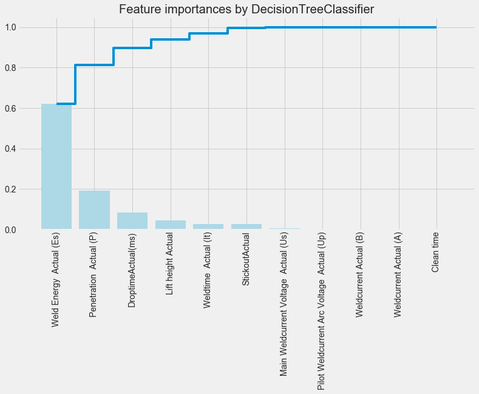

```python
plt.style.use('fivethirtyeight')
plt.rcParams['figure.figsize'] = (12,6)

## plot the importances ##
importances = dtree.feature_importances_
feat_names = RB400.drop(columns = ['Type'],axis=1).columns


indices = np.argsort(importances)[::-1]
plt.figure(figsize=(12,6))
plt.title("Feature importances by DecisionTreeClassifier")
plt.bar(range(len(indices)), importances[indices], color='lightblue',  align="center")
plt.step(range(len(indices)), np.cumsum(importances[indices]), where='mid', label='Cumulative')
plt.xticks(range(len(indices)), feat_names[indices], rotation='vertical',fontsize=14)
plt.xlim([-1, len(indices)])
plt.show()
```

```python
# Visualize the Decision Tree Classifier
```